# Bennett Institute: Copiloting review 2022

Lisa Hopcroft

2023-02-22

# Quantitative description

The SQLite file was last modified on 2023-02-17. Other relevant start/end dates are shown in the table below.

| variable | from | to |
| --- | --- | --- |
| Applications (submitted) | 2022-12-16 00:00:00 | 2023-02-01 00:00:00 |
| Applications (approved) | 2021-06-15 00:00:00 | 2023-02-16 00:00:00 |
| Workspaces | 2020-09-30 00:00:00 | 2023-02-09 00:00:00 |
| Jobs (start) | 2020-10-16 11:30:49 | 2023-02-16 10:51:56 |
| Jobs (end) | 2020-10-16 11:30:49 | 2023-02-16 11:00:02 |
| Releases | 2021-07-28 00:00:00 | 2023-02-16 00:00:00 |

## Overview: numbers of organisations, projects, copilots etc

We have 12 active co-pilots:

- acagreen17
- alexwalkerepi
- andrewscolm
- brianmackenna
- ccunningham101
- HelenCEBM
- Jongmassey
- LFISHER7
- LindaNab
- milanwiedemann
- robinyjpark
- wjchulme

Find some overall counts in Table 1 below.

Table 1: Overall counts (as of 2023-02-17)

|  | n |
| --- | --- |
| Total number of projects | 43 |
| Projects assigned co-pilots | 43 |
| Projects with outputs | 26 |
| Projects without outputs | 17 |
| Number of active copilotsa | 12 |
| Number of organisations with pilots | 21 |

aWe have at least 1 former co-pilot that is not included in the list above

Projects may consist of multiple workspaces. A count of projects and workspaces per organisation is provided in the Table 2.

Table 2: Number of projects and workspaces per organisation

| Organisation | Number of projects | Number of workspaces |
| --- | --- | --- |
| University of Bristol | 8 | 37 |
| NHSE/I | 6 | 9 |
| NHSX | 4 | 11 |
| ONS | 2 | 4 |
| PHC, University of Oxford | 2 | 2 |
| PrescQIPP | 2 | 2 |
| QMUL | 2 | 2 |
| The UK Renal Registry | 2 | 3 |
| University of Liverpool | 2 | 3 |
| University of Manchester | 2 | 35 |
| GraphNet | 1 | 4 |
| ISARIC | 1 | 1 |
| King's College London | 1 | 1 |
| Nuffield Trust | 1 | 2 |
| Public Health England | 1 | 2 |
| Royal Devon & Exeter NHS Foundation Trust and University of Exeter | 1 | 2 |
| UKHSA | 1 | 1 |
| University of Glasgow | 1 | 1 |
| University of Leeds | 1 | 1 |
| University of Nottingham | 1 | 1 |
| University of Surrey | 1 | 1 |
| Total | 43 | 125 |

## Copiloted output releases: how many have there been and how long do they take to generate

### Projects with releases

There are 26 projects with outputs.

See Table 3 for the number of files released from each project and the time (in days) to first release. Summary statistics for these values are provided in Tables 4 and 6 respectively.

Note that the time for the first release is calculated as the number of days between (1) the first workspace having been created and (2) the first release having been made (i.e., the release need not originate from the first workspace created for the project).

Table 3: Project release details: number of files and time to first release

| Project | Organisation | Number of files released | Time to first release (in days) | Release within 28 days | Release within 56 days | Release within 90 days | Release (no limit) |
| --- | --- | --- | --- | --- | --- | --- | --- |
| COVID-19 vaccine coverage and effectiveness in chronic kidney disease patients | The UK Renal Registry | 71 | 3 | TRUE | TRUE | TRUE | TRUE |
| BRIT Antibiotic Research | University of Manchester | 1,331 | 5 | TRUE | TRUE | TRUE | TRUE |
| Understanding and adjusting for bias in OpenSAFELY COVID testing data | ONS | 14 | 9 | TRUE | TRUE | TRUE | TRUE |
| Validation of the OpenSAFELY kidney codes | The UK Renal Registry | 70 | 11 | TRUE | TRUE | TRUE | TRUE |
| Prostate Cancer PSA Testing | NHSE/I | 2 | 13 | TRUE | TRUE | TRUE | TRUE |
| Investigating events following SARS-CoV-2 infection | University of Bristol | 511 | 19 | TRUE | TRUE | TRUE | TRUE |
| Direct Oral Anticoagulant (DOAC) prescribing during COVID-19 | PrescQIPP | 48 | 22 | TRUE | TRUE | TRUE | TRUE |
| GermDefence | University of Bristol | 11 | 29 | FALSE | TRUE | TRUE | TRUE |
| Impact of covid-19 on long-term healthcare use and costs in children and young people | ISARIC | 359 | 29 | FALSE | TRUE | TRUE | TRUE |
| Uptake of 'NHS at Home' interventions during COVID-19 | NHSE/I | 376 | 41 | FALSE | TRUE | TRUE | TRUE |
| Covid-19 antimicrobial stewardship | UKHSA | 25 | 42 | FALSE | TRUE | TRUE | TRUE |
| BMI and HbA1c | QMUL | 296 | 43 | FALSE | TRUE | TRUE | TRUE |
| Investigating the effectiveness of the COVID-19 vaccination programme in the UK | University of Bristol | 280 | 43 | FALSE | TRUE | TRUE | TRUE |
| Impacts of Healthcare Disruption on Avoidable Hospitalisations | University of Liverpool | 4 | 54 | FALSE | TRUE | TRUE | TRUE |
| Surveillance of psychiatric emergencies over time to investigate the effect of COVID-19 on mental health. A cohort study using OpenSafely | PHC, University of Oxford | 45 | 54 | FALSE | TRUE | TRUE | TRUE |
| lockdown-and-vulnerable-groups | University of Bristol | 56 | 67 | FALSE | FALSE | TRUE | TRUE |
| Deaths at home during COVID-19 | Nuffield Trust | 45 | 68 | FALSE | FALSE | TRUE | TRUE |
| Early Inflammatory Arthritis during COVID-19 | King's College London | 86 | 69 | FALSE | FALSE | TRUE | TRUE |
| long-covid-risk-factors | University of Bristol | 185 | 70 | FALSE | FALSE | TRUE | TRUE |
| Cancer Surgery Service Evaluation | University of Leeds | 60 | 88 | FALSE | FALSE | TRUE | TRUE |
| FLUCATS | University of Liverpool | 9 | 119 | FALSE | FALSE | FALSE | TRUE |
| Effects of COVID-19 on people with diabetes | University of Manchester | 23 | 121 | FALSE | FALSE | FALSE | TRUE |
| PostOpCovid | University of Nottingham | 58 | 137 | FALSE | FALSE | FALSE | TRUE |
| Care Home Prescribing | NHSE/I | 24 | 154 | FALSE | FALSE | FALSE | TRUE |
| Antidepressants | NHSE/I | 1 | 264 | FALSE | FALSE | FALSE | TRUE |
| Impact of the COVID pandemic on FIT (stool) testing | Royal Devon & Exeter NHS Foundation Trust and University of Exeter | 1 | 390 | FALSE | FALSE | FALSE | TRUE |

Summary of number of files released can be seen in Table 4.

Table 4: Summary statistics for the total number of files released per project

| statistic | value |
| --- | --- |
| Min. | 1.0 |
| 1st Qu. | 16.2 |
| Median | 52.0 |
| Mean | 153.5 |
| 3rd Qu. | 160.2 |
| Max. | 1,331.0 |

A histogram of the number of files **per project** is shown in Figure 1 below.

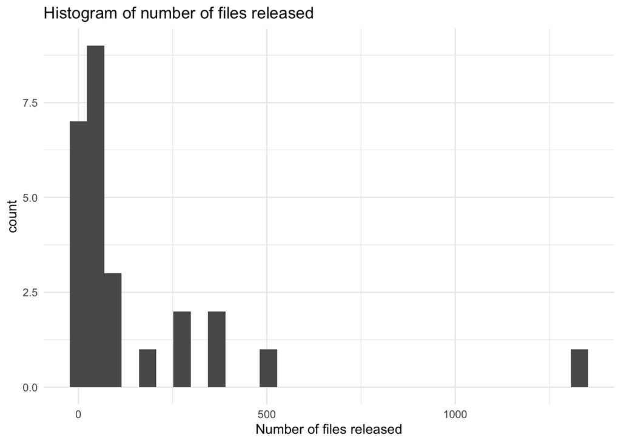

Figure 1: Histogram of number of files

The same data shown as a boxplot Figure 2 below.

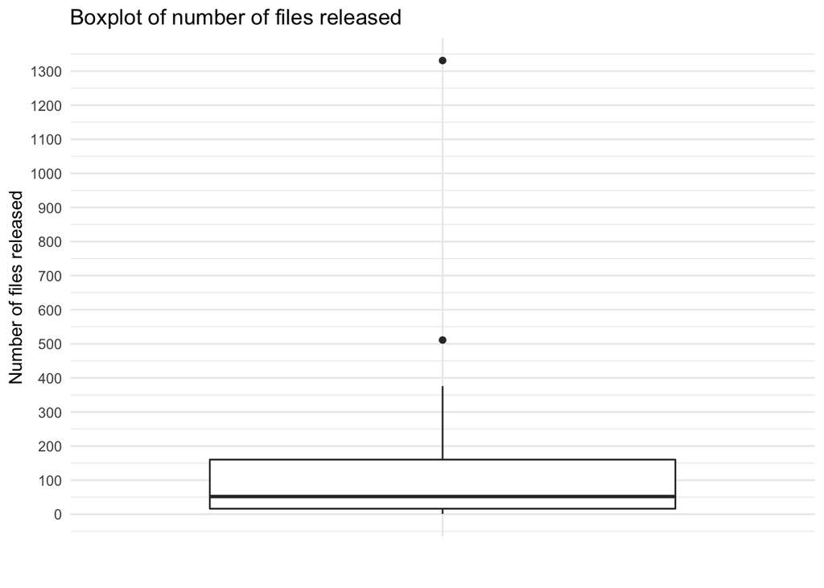

Figure 2: Boxplot of number of files

Summary of time to release by limits, by year, can be seen in Table 5.

Table 5: Number of releases within limits per year

| year | Number released within 28 days | Number released within 56 days | Number released within 90 days | Percentage released within 28 days | Percentage released within 56 days | Percentage released within 90 days | Total numer of projects |
| --- | --- | --- | --- | --- | --- | --- | --- |
| 2021 | 4 | 6 | 6 | 40.0 | 60.0 | 60.0 | 10 |
| 2022 | 3 | 9 | 14 | 18.8 | 56.2 | 87.5 | 16 |
| Total | 7 | 15 | 20 | 26.9 | 57.7 | 76.9 | 26 |

Summary of time to release by statistics, overall, can be seen in Table 6.

Table 6: Summary statistics for the number of days until first release per project

| statistic | value |
| --- | --- |
| Min. | 3.00 |
| 1st Qu. | 23.75 |
| Median | 48.50 |
| Mean | 75.54 |
| 3rd Qu. | 83.50 |
| Max. | 390.00 |

A histogram of the number of days until the first release **per project** is shown in Figure 3 below.

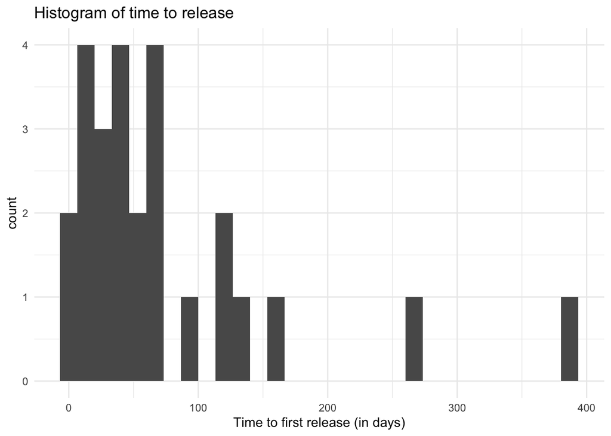

Figure 3: Histogram of time to first release (in days)

The same data shown as a boxplot Figure 4 below.

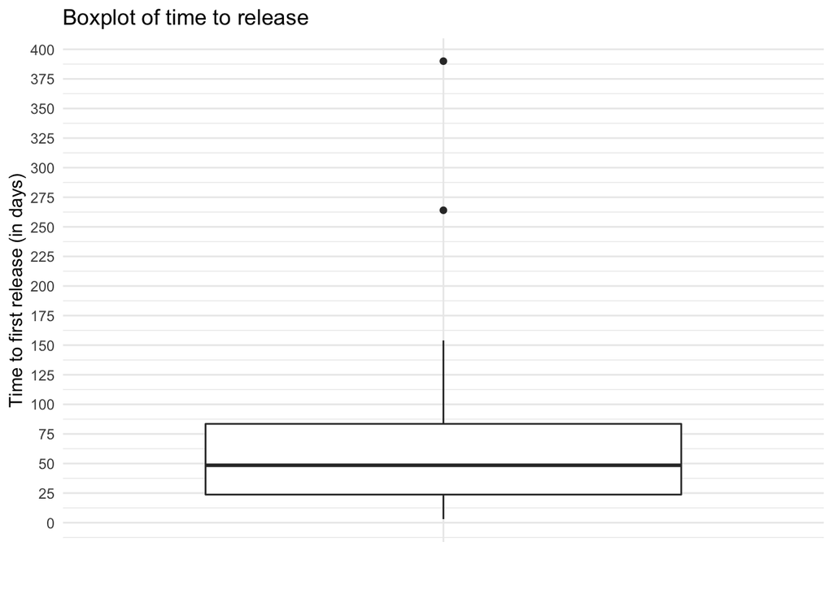

Figure 4: Boxplot of time to first release (in days)

### Projects without releases

Of the 17 projects without outputs, 2 projects were created within the last 28 days.

The remaining 15 projects are listed in Table 7.

Table 7: Projects without releases

| Project | Organisation | Number of days since project was created | Number of days since first workspace was created |
| --- | --- | --- | --- |
| Graphnet-OpenSAFELY-Test | GraphNet | 623 days | 623 days |
| Vaccine Eligibility | NHSX | 623 days | 807 days |
| Jonny Pearson | NHSX | 623 days | 729 days |
| Online Consultations | NHSX | 623 days | 729 days |
| Video Group Clinics | NHSX | 623 days | 667 days |
| Vaccine Regression Discontinuity | University of Bristol | 623 days | 708 days |
| covid-unvaccinated-descriptive | University of Bristol | 512 days | 512 days |
| Ethnic disparities in COVID-19 outcomes in London | Public Health England | 484 days | 476 days |
| Long Covid (diagnosis interval) | NHSE/I | 434 days | 434 days |
| BMI and Metabolic Markers | QMUL | 356 days | 355 days |
| Suicide deaths after healthcare contact in primary care | NHSE/I | 328 days | 244 days |
| MAINROUTE | PHC, University of Oxford | 328 days | 328 days |
| Incidence of mental illness following coronavirus infection in the community | ONS | 253 days | 245 days |
| Long-term kidney outcomes following hospitalisation with Covid-19 | University of Glasgow | 213 days | 153 days |
| Prostate cancer incidence and prevalence in the COVID-19 pandemic | University of Surrey | 104 days | 71 days |

## Applications

Note that application review time is calculated as the number of days between: the *application submission date* (`applications_application.submitted_at`) and the *application approved date* (`applications_application.approved_at`).

The field `applications_application.submitted_at` was [added on 13th December 2022](https://github.com/opensafely-core/job-server/commit/680f40ff1a5e99eafc4b0b8330e9b7e1d7078d79) so we will only have this data for applications submitted after this date.

We also need to bear in mind that early projects would have been approved and administered using the old ‘paper’-based system; the intention is to add these to the database over time, but this may not be complete and/or dates may only reflect the date on which they are added to the system.

Of the 43 external projects, 24 (55.8%) are represented in the applications table.

Those that are not are listed below (in order form the oldest to the newest):

Table 8: External projects for which we have no applications data

| Project | Organisation | Date that the project was created | Date on which the first workspace was created |
| --- | --- | --- | --- |
| Vaccine Eligibility | NHSX | 2021-06-09 | 2020-12-07 |
| Jonny Pearson | NHSX | 2021-06-09 | 2021-02-23 |
| Online Consultations | NHSX | 2021-06-09 | 2021-02-23 |
| Vaccine Regression Discontinuity | University of Bristol | 2021-06-09 | 2021-03-16 |
| Video Group Clinics | NHSX | 2021-06-09 | 2021-04-26 |
| Graphnet-OpenSAFELY-Test | GraphNet | 2021-06-09 | 2021-06-09 |
| GermDefence | University of Bristol | 2021-09-06 | 2021-09-09 |
| Antidepressants | NHSE/I | 2021-09-08 | 2021-10-06 |
| covid-unvaccinated-descriptive | University of Bristol | 2021-09-28 | 2021-09-28 |
| Direct Oral Anticoagulant (DOAC) prescribing during COVID-19 | PrescQIPP | 2021-11-24 | 2021-11-24 |
| Long Covid (diagnosis interval) | NHSE/I | 2021-12-15 | 2021-12-15 |
| Uptake of 'NHS at Home' interventions during COVID-19 | NHSE/I | 2022-01-31 | 2022-02-16 |
| Impact of covid-19 on long-term healthcare use and costs in children and young people | ISARIC | 2022-02-15 | 2022-02-17 |
| Deaths at home during COVID-19 | Nuffield Trust | 2022-02-25 | 2022-02-25 |
| BMI and Metabolic Markers | QMUL | 2022-03-03 | 2022-03-04 |
| lockdown-and-vulnerable-groups | University of Bristol | 2022-03-18 | 2022-03-18 |
| MAINROUTE | PHC, University of Oxford | 2022-03-31 | 2022-03-31 |
| BMI and HbA1c | QMUL | 2022-04-07 | 2022-04-07 |
| Impact of the COVID pandemic on FIT (stool) testing | Royal Devon & Exeter NHS Foundation Trust and University of Exeter | 2022-05-17 | 2021-04-20 |

| count | n |
| --- | --- |
| Applications (n) | 24 |
| With submission date | 1 |
| With approved date | 17 |
| With submission after approve | 0 |

Those that do not have an approved date are as follows:

Table 9: External projects that have an application yet to be approved

| Project | Organisation | Date that the project was created | Date on which the first workspace was created | Date on which the application was submitted |
| --- | --- | --- | --- | --- |
| Care Home Prescribing | NHSE/I | 2021-09-08 | 2021-09-08 |  |
| Prostate Cancer PSA Testing | NHSE/I | 2021-10-14 | 2021-10-14 |  |
| Effects of COVID-19 on people with diabetes | University of Manchester | 2021-10-25 | 2021-10-26 |  |
| Ethnic disparities in COVID-19 outcomes in London | Public Health England | 2021-10-26 | 2021-11-03 |  |
| Cancer Surgery Service Evaluation | University of Leeds | 2022-02-04 | 2022-02-07 |  |
| long-covid-risk-factors | University of Bristol | 2022-02-22 | 2022-02-22 |  |
| Investigating events following SARS-CoV-2 infection | University of Bristol | 2022-05-30 | 2021-09-29 |  |

Table 10: External projects where approval happens before creation

| Project | Organisation | Date that the project was created | Date on which the first workspace was created | Date on which the application was submitted |
| --- | --- | --- | --- | --- |

So we have valid, completed application data for 1 projects.

Table 11: External projects with valid, completed applications

| Project | Organisation | Date that the project was created | Date on which the first workspace was created | Date on which the application was submitted |
| --- | --- | --- | --- | --- |
| Comparison of risk factors for hospitalizations and death from winter infections | University of Bristol | 2023-01-11 | 2023-02-06 | 2023-01-05 |

Summary statistics for the number of days to application approval

Table 12: Summary statistics for number of days to application approval

| statistic | value |
| --- | --- |
| Min. | 6 |
| 1st Qu. | 6 |
| Median | 6 |
| Mean | 6 |
| 3rd Qu. | 6 |
| Max. | 6 |

The same value is represented below in a histogram.

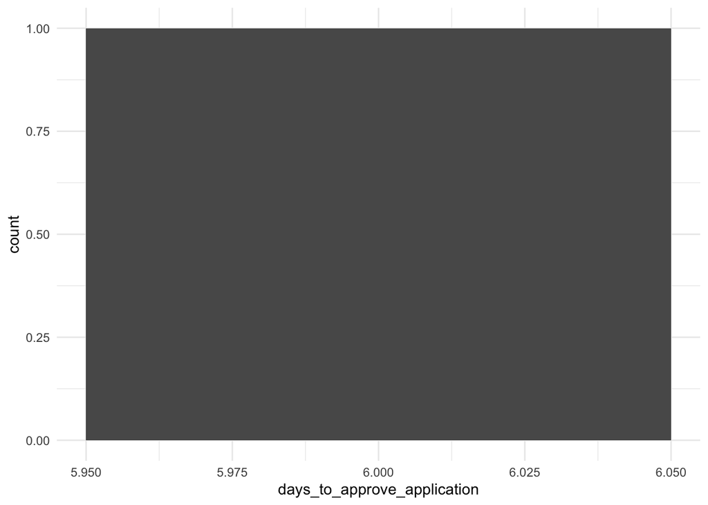